# DS Python Test (Task3)

In this notebook we are addressing task 3

- Task1: Understanding User Journeys (Mandatory)
- Task2: Finding the Longest Way to TripAdvisor (Optional)
- **Task3: User Engagement and Retention Analysis (Optional)**

This notebook will be a walktrough of the process to obtain the results.

## Context

In this case, we are talking about a trip advisor session, which is defined from the moment a user enters a link to the last consecutive trip_advisor link is clicked.

This will define certain cases or `states` of a session. For instance, if there is only one link of trip advisor.

- If there is only one trip advisor link this is a `init-end` session. Because it ended and started in the same link.
- There is also the cases where there is only two links, which will correspond to an `init` and to an `end` state correspondingly.
- Additionaly there are cases where there are more than two trip_advisor consecutive links, which will correspond as a general form to an `init`, `during`, `during`, ..., `during`, `end` case for each instance.

## Import Libraries

```python
import os
import pandas as pd
import matplotlib.pyplot as plt
import numpy as np

from urllib.parse import urlparse
```

## Set Configuration and constants

```python
# Constants
URL_TRIPADVISOR = 'https://www.tripadvisor.com'
URL_EMPTY_STRING = 'https://www.this_is_an_empty_string.com'

# Configuration
pd.set_option('display.max_rows', 100)
pd.set_option('display.max_colwidth', None)
```

## Initial data read

```python
# Proccessed data:
df = pd.read_parquet('../data/processed/data.parquet')
```

## Helper functions:

```python
# Additional data process:
def define_session_number_per_user(data):
    """This function removes consecutive duplicates from a url.

    Parameters
    ----------
    data: pd.DataFrame
        Original processed data.

    Returns
    -------
    df: pd.DataFrame
        Returns a Dataframe with an additional session_nb column
        for each session of each user.
    """
    new_col = 'session_nb'
    df = data.copy()
    df.loc[df.session_ta.str.startswith('init'), new_col] = 1
    df.loc[~df.session_ta.str.startswith('init'), new_col] = 0
    df[new_col] = df[new_col].cumsum().astype('int')
    return df
```

## Task 3: User Engagement and Retention Analysis (Optional)

### Objective:

Analyze user engagement and retention with respect to TripAdvisor links. Are there particular features or pages that lead to higher engagement? Identify and visualize drop-off points or areas where users might abandon the journey to TripAdvisor.

```python
# Lets modify original dataframe, adding session_numbers per user. and joined links
data = df.groupby('userid').apply(define_session_number_per_user).reset_index(drop=True)
data['links'] = (data['referrerurl'] + ',' + data['targeturl']).str.split(',')
```

```python
# Now we can make a session-wise analysis:
# For each session lets obtain the 'session_time',
# the minimun date, and the links (only trip advisor links)
data_sessionwise = data.groupby(['userid', 'session_nb']).agg(
    session_time = ('eventtimestamp', lambda x: x.max()-x.min()),
    session_min_date = ('eventtimestamp', 'min'),
    links_per_session = ('links', lambda x: [v for v in x.sum() if URL_TRIPADVISOR in v]),
)

# With this information now we can compute the "session max_date"
# We can as well get insight on the unique links per session and how much they are
data_sessionwise['session_max_date'] = data_sessionwise['session_min_date'] + data_sessionwise['session_time']
data_sessionwise['unique_links_per_session'] = data_sessionwise['links_per_session'].apply(lambda x: list(set(x)))
data_sessionwise['nunique_links_per_session'] = data_sessionwise['links_per_session'].apply(lambda x: len(set(x)))

# And we can get which was the first and last link.
data_sessionwise['first_link'] = data_sessionwise['links_per_session'].apply(lambda x: x[0])
data_sessionwise['last_link'] = data_sessionwise['links_per_session'].apply(lambda x: x[-1])

# With these information we can get a grasp of a high engagement condition:
# In this case, high engagement is defined as having a session time greater (or equal) than the 90th quantile of the session time.
high_engagement_condition = data_sessionwise.session_time >= data_sessionwise.session_time.quantile(0.90)
#low_engagement_condition = data_sessionwise.session_time <= data_sessionwise.session_time.quantile(0.01)
data_sessionwise.loc[high_engagement_condition,'high_engagement'] = 1
#data_sessionwise.loc[low_engagement_condition,'high_engagement'] = 0
```

```python
# High engagement links
high_engagement_links = pd.Series(
    data_sessionwise[
        data_sessionwise.high_engagement == 1
    ].links_per_session.sum()
)

# Lets parse the url, get the path and split the words,
# and then get the initial (most representative) word of the path
high_engagement_links_path_res = high_engagement_links\
.apply(lambda x: urlparse(x).path.split('-')[0])\
.str.lower()\
.str.replace('.html', '')\
.value_counts(normalize=True) * 100
```

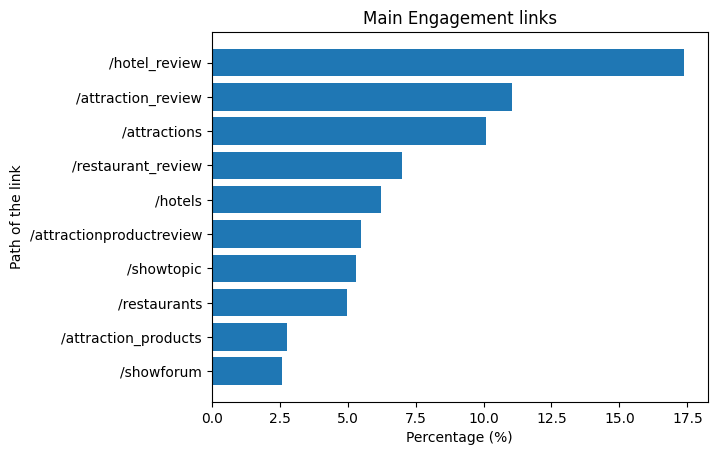

```python
# Data Viz
plt.title('Main Engagement links')
plt.barh(high_engagement_links_path_res.head(10).sort_values().index, high_engagement_links_path_res.head(10).sort_values(),)
plt.ylabel('Path of the link')
plt.xlabel('Percentage (%)')
plt.show()
```

We can see that `hotel review` represents the most engaging website. This may be due to the fact that hotel's review are a usual trait to check in a hotel where someone is going to go. Actually in the top 5, 3 of them are reviews: hotel, attraction and restaurant, which make sense since people may spent time checking these sites.

We also have hotels and attractions, this also makes sense because maybe users spent time looking at different options, increasing the engagement.

As a reference, here there are the top 40 most engaging links:

```python
high_engagement_links_path_res.head(40)
```

```
/hotel_review                 17.383362
/attraction_review            11.033334
/attractions                  10.076304
/restaurant_review             7.001520
/hotels                        6.220699
/attractionproductreview       5.499693
/showtopic                     5.317016
/restaurants                   4.961363
/attraction_products           2.772479
/showforum                     2.596269
/search                        2.505739
/                              2.410359
/showuserreviews               2.184034
/tourism                       2.069255
                               1.775033
/smartdeals                    1.482427
/vacationrentalreview          1.194672
/searchforums                  1.096059
/commerce                      0.717773
/restaurantsnear               0.678974
/shoppingcartcheckout          0.648259
/hotelslist                    0.593294
/vacationrentals               0.570662
/hotelsnear                    0.523780
/faq_answers                   0.379902
/locationphotodirectlink       0.376669
/attractionsnear               0.363736
/cheapflightssearchresults     0.350803
/registrationcontroller        0.315238
/shoppingcart                  0.305538
/userreviewedit                0.299072
/bookings                      0.299072
/clientlink                    0.294222
/trips                         0.281289
/vracsearch                    0.266740
/attractionbookingdetails      0.263507
/flights                       0.227941
/faq                           0.224708
/url                           0.216625
/vacation_packages             0.203692
Name: proportion, dtype: float64
```

```python
# Drop off points

# We will define the drop off points as the most relevant path segment of the last link of a session.
drop_off_links_path_res = data_sessionwise\
.last_link\
.apply(lambda x: urlparse(x).path.split('-')[0])\
.str.lower()\
.value_counts(normalize=True) * 100
```

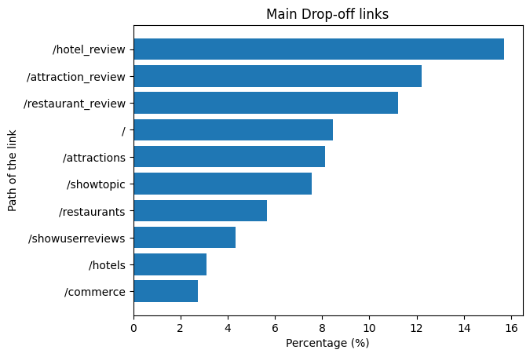

```python
# Data viz:
plt.title('Main Drop-off links')
plt.barh(drop_off_links_path_res.head(10).sort_values().index, drop_off_links_path_res.head(10).sort_values(),)
plt.ylabel('Path of the link')
plt.xlabel('Percentage (%)')
plt.show()
```

As for the drop off points. We find that the Hotel, Atteraction and Restaurant reviews are the last point of contact of a user. This may be due to the fact that the user already satisfies it's desire to see which specific element is worth and now, knowing the review, trip advisor is no longer used. Then the main page is show, this might indicate that users might access to trip advisor and not do anything. As a refference as well, here are the top 40 drop off points

```python
drop_off_links_path_res.head(40)
```

```
last_link
/hotel_review                     15.700054
/attraction_review                12.213176
/restaurant_review                11.229780
/                                  8.445635
/attractions                       8.122121
/showtopic                         7.546867
/restaurants                       5.651848
/showuserreviews                   4.324585
/hotels                            3.109802
/commerce                          2.740225
/attractionproductreview           2.652384
/attraction_products               2.052491
/smartdeals                        1.872523
                                   1.385110
/faq_answers                       1.196572
/tourism                           1.191216
/locationphotodirectlink           1.016604
/hotelslist                        0.901982
/search                            0.694162
/widgetembed                       0.664167
/restaurantsnear                   0.650241
/hotelsnear                        0.567756
/vacationrentalreview              0.446706
/attractionsnear                   0.415640
/externallinkinterstitial          0.287092
/shoppingcartcheckout              0.271023
/showforum                         0.258168
/cheapflightssearchresults         0.235672
/vacationrentals                   0.224960
/airline_review                    0.217461
/url                               0.194965
/singleclickoptout                 0.174612
/flights                           0.163899
/registrationcontroller            0.160686
/vacation_packages                 0.149973
/travel                            0.145688
/clientlink                        0.112480
/hotelbookingroomselectionhtml     0.110337
/userreviewedit                    0.102839
/articles                          0.102839
Name: proportion, dtype: float64
```

It is worth noting that hotel, attraction and restaurant reviews are both a mechanism of high engagement and a drop-off point.